# SBW x Fire Interaction

Jack A Goldman

2024-02-23

# The impact of the spatial legacies of spruce budworm defoliation on wildfire burn severity and post-fire recovery

## Background

To date, current evidence on the impact of the spatial legacies of defoliation is mixed, reporting positive, negative and neutral effects. This uncertainty is in part driven by the ability to detect where particular changes in fuel or legacies of defoliation have overlapped with wildfires. Recent advances in remote sensing offers exciting prospects to utilize novel spatial data combined with thoughtful experimental design to reduce uncertainty around the effects of spruce budworm defoliation on fuels and wildfire behaviour. We are now able to remove or reduce uncertainty through better experimental design and approaches to big data problems. Here, we used a paired design within fires that have both areas that were affected by insect defoliation and not affected to attempt to resolve this uncertainty,

## Questions

The overarching question is: *how do the spatial legacies of spruce budworm defoliation influence wildfire burn severity and forest recovery in the boreal forest?*

Specifically we will address the following questions:

1. How does spruce budworm defoliation influence burn severity?
   1. Is there a difference in median severity between defoliated and non-defoliated fires?
   2. Is there a difference in severity extremes between defoliated and non-defoliated fires
   3. Is there a difference in variability in burn severity between defoliated and non-defoliated fires
2. How does spruce budworm defoliation influence post-fire recovery?
   1. Is there a difference in forest recovery 10 years post-fire between defoliated and non-defoliated fires?
   2. Is there a difference in forest recovery between 1-5 years and 6-10 years between defoliated and non-defoliated fires?
3. Is the strength of the relationship between defoliation intensity (synthetic index) and burn severity or forest recovery greater than independent metrics of defoliation?
4. Does defoliation intensity (synthetic index) capture more variation in burn severity and forest recovery relative to defoliation metrics modeled independently?

## Methods

### Structural Equation Model

The second part of the analysis looks at the effects of defoliation intensity on burn severity and forest recovery following fire. Defoliation alters fuel structure and fuel load and is expected to cause influence fire behaviour. Previous studies in Ontario have shown that defoliation can alter fire behaviour for up to 15 following defoliation [@james2017], this period is commonly referred to as the “window of opportunity”.

Spruce budworm defoliation is multivariate in nature. The effects of spruce budworm defoliation can be described by the presence and absence of defoliation, the time since defoliation to the time of fire and the number of years that an area was defoliated (a proxy for defoliation load). It is common practice for studies that concerned with the effects of spruce budworm defoliation on wildfire to use a since predictor, or build multiple sequential models to incorporate the multivariate nature of defoliation [@james2017 @james2011 @candau2018].

Structural equation models allow for the multivariate nature of defoliation by creating composite variable that allows us to combine the variation explained by multiple predictors into a synthetic index. Using structural equation models, we will combine create a synthetic index called defoliation intensity which combines defoliation presence/absence, time since defoliation and number of years defoliated.

In our model, defoliation intensity will effect for burn severity and forest recovery. Below is the directed acyclic graph (DAG) of our a priori causal hypothesis.

[interactive chart not shown]

In this DAG we see that time since defoliation, and number of years defoliated are combined to form the synthetic index (defoliation intensity) which is then used to predict the effects on burn severity and forest recovery. Defoliation intensity will indirectly effect forest recovery by altering stand structure and forest composition prior to fire, which will impact the number and distribution species and their seed banks that are able to establish post fire, thus affecting the recovery trajectory. Similarly, defoliation intensity will effect burn severity by either increasing or decreasing severity which will lead to a change in the recovery trajectory by either increasing or decreasing the slope of recovery.

## Preliminary results

#### How does spruce budworm defoliation influence burn severity?

**Results from Pairwise T-test on severity between defoliated and non-deoliated**

| Test | t-value | df | P-value |
| --- | --- | --- | --- |
| Median Severity | -2.16095466572192 | 69 | 0.034 |
| Extreme Severity | 1.13546435208255 | 69 | 0.260 |
| Variability in Severity | 0.960918785574236 | 69 | 0.340 |

Severity visualization

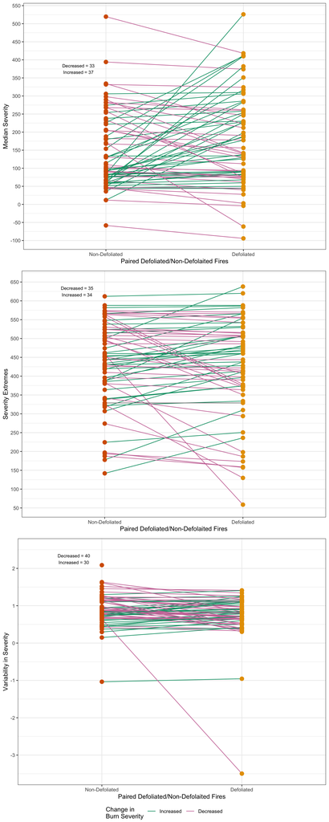

#### How does spruce budworm defoliation influence post-fire recovery?

**Results from Pairwise T-test on Slope of Recovery Between Defoliated and Non-Deoliated**

| Test | t-value | df | P-value |
| --- | --- | --- | --- |
| 10yr post-fire | -0.0437357769415193 | 69 | 0.965 |
| 1-5yr post-fire | 0.0732978798141436 | 69 | 0.942 |
| 6-10yr post-fire | 0.160403093096384 | 69 | 0.873 |

```r
targets::tar_read(lolliplot_slope)
```

[output not shown]

[output not shown]

#### Is there a difference in the direction of the effects ?

```r
chisq_table(targets::tar_read(chisq_result))
```

**Significant Difference in Direction of Trend between Paired Fires**

Results from chi-square tst

| Independent Variable of Interest | x² | df | P-value |
| --- | --- | --- | --- |
| Median Severity | 0.457 | 1 | 0.499 |
| Extreme Severity | 0.029 | 1 | 0.865 |
| Varibility in Severity | 2.857 | 1 | 0.091 |
| 10 yr slope of recovery | 1.029 | 1 | 0.310 |
| 1-5 yr slope of recovery | 0.114 | 1 | 0.735 |
| 6-10 yr slope of recovery | 0.457 | 1 | 0.499 |

#### Does a synthetic index of defoliation intensity capture more variation in burn severity and forest recovery relative to defoliation metrics modelled using an interaction? Are the strengths of the effects different?

First, we fit repeated measures linear mixed effects models with an interaction terms between time since defoliation and cumulative years of defoliation for each response variable:

$Y_{i} = \beta_0 + \beta_1X_{1i} + \beta_2X_{2i} +\beta_3X_{1i}X_{2i} + u_{i} \epsilon_{i}$.

Where Y = the response variable of interest and i = for the i th fire, $\beta_1X_{1i}$ = time since disturbance (tsd), $\beta_2X_{2i}$ = cumulative years of defoliation (cyd), $+\beta_3X_{1i}X_{2i}$ = interaction between tsd and cyd, $u_{i}$ = random intercept for paired fire id.

Median Severity

**Median Burn Severity**

Results from repeated measures hierachical linear mixed model fit in nlme

| term | estimate | std.error | df | statistic | p.value |
| --- | --- | --- | --- | --- | --- |
| (Intercept) | 148.5519561 | 13.564996 | 69 | 10.95112401 | 0.000 |
| tsd | 0.1194051 | 2.221304 | 67 | 0.05375453 | 0.957 |
| cumltve_yrs | -5.6309938 | 7.704273 | 67 | -0.73089228 | 0.467 |
| tsd:cumltve_yrs | 1.7565995 | 1.268738 | 67 | 1.38452499 | 0.171 |

Extreme Severity

**Burn Severity Extremes**

Results from repeated measures hierachical linear mixed model fit in nlme

| term | estimate | std.error | df | statistic | p.value |
| --- | --- | --- | --- | --- | --- |
| (Intercept) | 431.015128 | 15.198599 | 69 | 28.358872 | 0.000 |
| tsd | -5.696929 | 1.924455 | 67 | -2.960281 | 0.004 |
| cumltve_yrs | -4.128863 | 6.749045 | 67 | -0.611770 | 0.543 |
| tsd:cumltve_yrs | 2.268256 | 1.119966 | 67 | 2.025289 | 0.047 |

Variability in Severity

**Variability in Burn Severity**

Results from repeated measures hierachical linear mixed model fit in nlme

| term | estimate | std.error | df | statistic | p.value |
| --- | --- | --- | --- | --- | --- |
| (Intercept) | 0.885112852 | 0.075651726 | 69 | 11.6998368 | 0.000 |
| tsd | -0.016773176 | 0.013062859 | 67 | -1.2840356 | 0.204 |
| cumltve_yrs | 0.021500616 | 0.045119739 | 67 | 0.4765235 | 0.635 |
| tsd:cumltve_yrs | 0.001450466 | 0.007408573 | 67 | 0.1957821 | 0.845 |

Slope of recovery 10 year

**Slope of Recovery 1-10 Years Post-Fire**

Results from repeated measures hierachical linear mixed model fit in nlme

| term | estimate | std.error | df | statistic | p.value |
| --- | --- | --- | --- | --- | --- |
| (Intercept) | 1.84723349 | 0.44525916 | 69 | 4.1486704 | 0.000 |
| tsd | -0.02679336 | 0.04001403 | 67 | -0.6695992 | 0.505 |
| cumltve_yrs | -0.16395671 | 0.14116052 | 67 | -1.1614913 | 0.250 |
| tsd:cumltve_yrs | 0.03577155 | 0.02351789 | 67 | 1.5210355 | 0.133 |

Slope of recovery 1-5 year

**Slope of Recovery 1-5 Years Post-Fire**

Results from repeated measures hierachical linear mixed model fit in nlme

| term | estimate | std.error | df | statistic | p.value |
| --- | --- | --- | --- | --- | --- |
| (Intercept) | 7.74731090 | 1.37382265 | 69 | 5.6392366 | 0.000 |
| tsd | -0.16753985 | 0.10026842 | 67 | -1.6709134 | 0.099 |
| cumltve_yrs | -0.10279099 | 0.35434595 | 67 | -0.2900865 | 0.773 |
| tsd:cumltve_yrs | 0.08959767 | 0.05910411 | 67 | 1.5159296 | 0.134 |

Slope of recovery 6-10 year

**Slope of Recovery 6-10 Years Post-Fire**

Results from repeated measures hierachical linear mixed model fit in nlme

| term | estimate | std.error | df | statistic | p.value |
| --- | --- | --- | --- | --- | --- |
| (Intercept) | -6.31023413 | 1.04229898 | 69 | -6.0541498 | 0.000 |
| tsd | 0.01438870 | 0.05223303 | 67 | 0.2754712 | 0.784 |
| cumltve_yrs | -0.19731614 | 0.18489980 | 67 | -1.0671517 | 0.290 |
| tsd:cumltve_yrs | 0.01998152 | 0.03087495 | 67 | 0.6471758 | 0.520 |

## Significance

Land managers in the boreal forest region require information about burn severity to address immediate hazards and outcomes resulting from wildfires. Understanding how previous disturbance history shapes patterns of burn severity is needed to guide management activities and ensure downstream ecosystem provisioning when threatened by multiple disturbances. Results from this chapter will provide a framework for modelling the effects of spruce budworm defoliation on wildfire severity and help managers identify areas that are at the highest risk of losing valuable ecosystem services.